# Integrated Gradient

We will talk about...

- Gradient-based attribution
- Integrated gradients for image
- (Layer) Integrated gradients for NLP

# Setup Basic Libraries

```python
import os
os.environ['CUDA_VISIBLE_DEVICES'] = "2"

import matplotlib.pyplot as plt
import torch

# Computer Vision related
import torchvision
import torchvision.models as models
import torchvision.transforms as T
from torchvision.io import read_image


# Huggingface related
from transformers import AutoModelForSequenceClassification, AutoTokenizer
```

# What is Gradient Attribution?

Have you ever heard about saliency map in computer vision field? It is simply a backpropagation of the output on the input image.

Suppose we have the model $f$ output probabilities for each class, and the input image $\mathbf{x}$ which has the label $i$

$$p_i=f(\mathbf{x})_i$$$$saliency=\frac{dp_i}{d\mathbf{x}}$$

Here is an example how the saliency map look like

[figure not shown]

## Other Similar Methods: Grad-CAM (2019)

Instead of backpropagating back to the image, it performs on the last convolution layer instead.

[figure not shown]

## Prepare the model and Image

```python
resnet = models.resnet18(pretrained=True, progress=False).eval()
_ = resnet.to('cuda')
```

```python
# ResNet transformation
transforms = torch.nn.Sequential(
        T.Resize([256, ]),
        T.CenterCrop(224),
        T.ConvertImageDtype(torch.float),
        T.Normalize([0.485, 0.456, 0.406], [0.229, 0.224, 0.225])
    )

resize = torch.nn.Sequential(
    T.Resize([256, ]),
    T.CenterCrop(224)
)
```

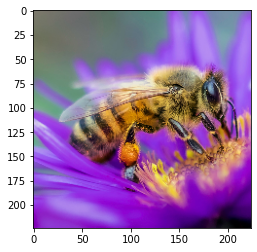

```python
# Load image with resize
image = resize(read_image('bee.jpg'))
# Transform to ResNet input
image_resnet = transforms(image)

# Show image
plt.imshow(T.ToPILImage()(image.to('cpu')))
```

# Model Sanity Check

Check if the model can predict this image correctly

```python
import json

with open('imagenet_class_index.json', 'r') as labels_file:
    labels = json.load(labels_file)

# Sanity check
predicted_label = resnet(image_resnet.unsqueeze(0).to('cuda')).argmax().cpu()
labels[str(int(predicted_label))]
```

```
['n02206856', 'bee']
```

# Gradient Computation

We setup simple function to compute the gradient on the input, $\partial p_i(f(x))/\partial x$, where $p_i$ is the probability of the target label $i$.

```python
def compute_gradients(images, target_class_idx):
    input_images = images.to('cuda').clone().detach().requires_grad_(True)
    logits = resnet(input_images)

    # Get the probabilities of the target class
    probs = torch.nn.functional.softmax(logits, dim=-1)[:, target_class_idx]

    probs.backward()

    return input_images.grad

tmp = image_resnet[None,:,:,:]
path_gradients = compute_gradients(
    images=tmp,
    target_class_idx=312) # Cricket
```

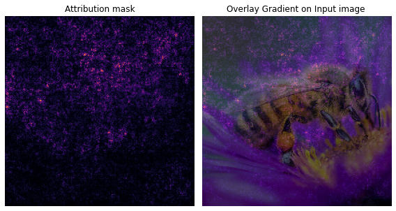

```python
# Display plot of the gradient to the image (Simple Saliency map)

attribution_mask = torch.sum(torch.abs(path_gradients[0]), dim=0).cpu()
fig, axs = plt.subplots(nrows=1, ncols=2, squeeze=False, figsize=   (8, 8))
axs[0, 0].set_title('Attribution mask')
axs[0, 0].imshow(attribution_mask, cmap=plt.cm.inferno)
axs[0, 0].axis('off')
axs[0, 1].set_title('Overlay Gradient on Input image ')
axs[0, 1].imshow(attribution_mask, cmap=plt.cm.inferno)
axs[0, 1].imshow(T.ToPILImage()(image.to('cpu')), alpha=0.4)
axs[0, 1].axis('off')
plt.tight_layout()
```

# Today: Integrated Gradient

From the paper: Axiomatic Attribution for Deep Networks (M. Sundararajan, 2017)

**Objective**: To show that their method is better than vanilla gradient based (Saliency map)

## Axioms

### Sensitivity

If the input is different from the baseline and the output also different, the attribution should be non-zero

**Example**: Vanilla gradient did not satisfy this. Consider the function $f(x) = 1-Relu(1-x)$.

Assume that baseline is $x'=0\rightarrow f(x')=0$, consider $x=2\rightarrow f(x)=1$ where the output is different. However, the gradient at $x=2$ is zero; thus, doesn't satisfy the sensitivity

### Implementation Invariance

Two functionally equivalent networks should have identical attributions for the same input and the baseline. For example, 200 layers of NN and 10 layers of NN which always output same value for same input, their attribute should be the same for an input.

**They prove that the integrated gradient satisfied both axioms**

## What is baseline input?

The baseline input can be consider as "absence" of input. Considering attribution as blaming the input, we need to think counterfactually if the part of input is ablated.

Example of baseline input

- **Image**: Completely black image (all zeros)
- **Text**: Embedding with padding
- **Sound**: Flat wave input

# Overall Steps for Intergated Gradient

## Step 1

Generate the baseline input. In case of image, we generate all-zero image to as the baseline

## Step 2

Compute the $\alpha$-blended between the baseline input and the actual input. For example, the cat images below.

[figure not shown]

## Step 3

Compute the gradient for all $\alpha$-blended images. Then estimate the attribute from the gradient and visualize with the original image.

[figure not shown]

## General Path Integrated Gradient

Let $x'$ is the baseline and $x$ is the input and $\gamma$ is the path from the baseline $\rightarrow$ input. We can compute the path integrated gradient as the following

$$IntegratedGrad(x) = \int_{\alpha=0}^{1}\frac{\partial F(\gamma(\alpha))}{\partial\gamma(\alpha)} \frac{\partial \gamma(\alpha)}{\partial\alpha} d\alpha$$

[figure not shown]

## Path Integrated Gradient

Let $x'$ is the baseline and $x$ is the input. We can compute the path integrated gradient as the following

$$IntegratedGrad(x) = (x-x')\int_{\alpha=0}^{1}\frac{\partial F(x'+\alpha\times(x-x'))}{\partial x} d\alpha$$

This is **straightline path** integrated gradient and we will always use this.

# Prepare straightline path image

So our bee is the input $x$ and the baseline is zeros image $x'$. We will perform $\alpha$-blending of $x'$ and $x$ so that $$ \gamma(\alpha)=x'+\alpha\times(x-x') $$

```python
m_steps = 50 # Path step
alphas = torch.linspace(start=0.0, end=1.0, steps=m_steps+1)

def interpolate_images(image, alphas):
    alphas_x = alphas[:, None, None, None]
    baseline_x = torch.zeros(1, *image.shape)
    input_x = torch.unsqueeze(image, dim=0)
    delta = input_x - baseline_x
    images = baseline_x +  alphas_x * delta
    return images.type(torch.uint8)

interpolated_images = interpolate_images(
    image=image,
    alphas=alphas
)
```

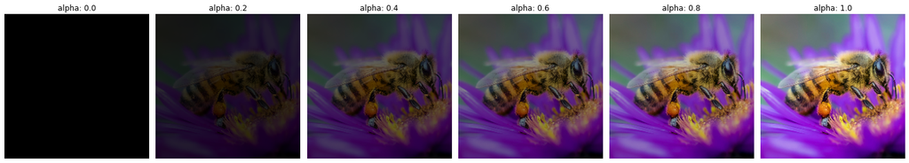

```python
fig = plt.figure(figsize=(20, 20))
i = 0
for alpha, img in zip(alphas[0::10], interpolated_images[0::10]):
    i += 1
    plt.subplot(1, len(alphas[0::10]), i)
    plt.title(f'alpha: {alpha:.1f}')
    plt.imshow(T.ToPILImage()(img.to('cpu')))
    plt.axis('off')
plt.tight_layout();
```

# Integral Approximation

It is well known that the integration is likely to be intractable. Therefore, we employ trapezoid approximation (the illustration below if you forgot about it)

$$IntegratedGrad(x) = (x-x')\int_{\alpha=0}^{1}\frac{\partial F(x'+\alpha\times(x-x'))}{\partial x} d\alpha\\ \sim (x-x')\times\sum_{k=0}^{m-1}\left(\frac{\partial F(x'+\frac{k}{m}\times(x-x'))}{\partial x} + \frac{\partial F(x'+\frac{k+1}{m}\times(x-x'))}{\partial x}\right)\times\frac{1}{2m}$$

[figure not shown]

```python
def integral_approximation(gradients):
    # riemann_trapezoidal
    grads = (gradients[:-1] + gradients[1:]) / 2.0
    integrated_gradients = torch.mean(grads, dim=0)
    return integrated_gradients
```

```python
# Combine them all!

def integrated_gradients(image, target_class_idx, m_steps=50, batch_size=1):

    # Split alpha according to the m_steps
    alphas = torch.linspace(start=0.0, end=1.0, steps=m_steps+1)

    # Initialize TensorArray outside loop to collect gradients.
    gradient_batches = torch.zeros(size=(m_steps+1, 3, 224,224))

    # Loop through each alpha blend
    for st_index in range(0, len(alphas), batch_size):
        ed_index = min(st_index + batch_size, len(alphas))
        alpha_batch = alphas[st_index: ed_index]

        # 2. Generate interpolated inputs between baseline and input.
        interpolated_path_input_batch = interpolate_images(image=image, alphas=alpha_batch)
        interpolated_path_input_batch = transforms(interpolated_path_input_batch)

        # 3. Compute gradients between model outputs and interpolated inputs.
        gradient_batch = compute_gradients(images=interpolated_path_input_batch, target_class_idx=target_class_idx)

        # Write batch indices and gradients to extend TensorArray.
        gradient_batches[st_index:ed_index] = gradient_batch

    # 4. Integral approximation through averaging gradients.
    avg_gradients = integral_approximation(gradients=gradient_batches)

    # 5. Scale integrated gradients with respect to input.
    integrated_gradients = (image - 0) * avg_gradients # 0 baseline
    return integrated_gradients
```

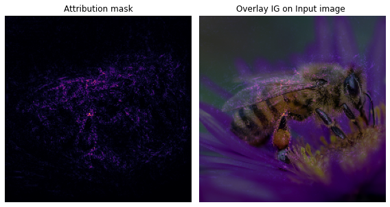

```python
def plot_image_IG(image, target_class_idx, m_steps=50, cmap=None, overlay_alpha=0.4):
    attributions = integrated_gradients(image=image,target_class_idx=target_class_idx, m_steps=m_steps)
    attribution_mask = torch.sum(torch.abs(attributions), dim=0)
    fig, axs = plt.subplots(nrows=1, ncols=2, squeeze=False, figsize=   (8, 8))
    axs[0, 0].set_title('Attribution mask')
    axs[0, 0].imshow(attribution_mask, cmap=cmap)
    axs[0, 0].axis('off')
    axs[0, 1].set_title('Overlay IG on Input image ')
    axs[0, 1].imshow(attribution_mask, cmap=cmap)
    axs[0, 1].imshow(T.ToPILImage()(image.to('cpu')), alpha=overlay_alpha)
    axs[0, 1].axis('off')
    plt.tight_layout()
    return fig

_ = plot_image_IG(image=image, target_class_idx=312, m_steps=240, cmap=plt.cm.inferno, overlay_alpha=0.4)
```

# How About Text?

Let's use the library **captum** (https://captum.ai/) to perform integrated gradient on BERT!

# Load NLI model

We will load the pre-trained BERT and tokenizer on SNLI

```python
# SNLI BERT tokenizer & model
tokenizer = AutoTokenizer.from_pretrained("textattack/bert-base-uncased-snli")
model = AutoModelForSequenceClassification.from_pretrained("textattack/bert-base-uncased-snli")
_ = model.eval()
```

```python
'''
Label:
0 - contradiction,
1 - entailment,
2 - neutral
'''

# HANS sample
premise = "If the artist slept, the actor ran."
hypothesis = "The artist slept."
label = 1

# Create tokenized inputs
inputs = tokenizer(premise, hypothesis, return_tensors='pt')

model(**inputs)
```

```
SequenceClassifierOutput(loss=None, logits=tensor([[-1.4935,  1.8938, -1.0490]], grad_fn=<AddmmBackward0>), hidden_states=None, attentions=None)
```

# Import captum

You might realize that the object name is "LayerIntegratedGradients" and wonder what is that "Layer" mean?

```python
from captum.attr import visualization as viz
from captum.attr import LayerConductance, LayerIntegratedGradients
```

# Layer Integrated Gradients

- x = "[CLS] aaa bbb ccc [SEP] ddd eee fff [SEP]
- x' = "[CLS] [PAD] [PAD] [PAD] [SEP] [PAD] [PAD] [PAD] [SEP]"

Let

- $f$ is the BERT model outputs the probability
- $f_i$ is the output of layer $i$ and $f_{i\rightarrow}$ is the model portion from layer $i$ to the output (or $f_{i\rightarrow}(f_i(x))=f(x))$

the integrated gradient at layer $i$ is

$$IntegratedGrad(x) = (f_i(x)-f_i(x'))\int_{\alpha=0}^{1}\frac{\partial f_{i\rightarrow}(f_i(x')+\alpha\times(f_i(x)-f_i(x')))}{\partial f_i(x)} d\alpha$$

```python
ref_token_id = tokenizer.pad_token_id # A token used for generating token reference
sep_token_id = tokenizer.sep_token_id # A token used as a separator between question and text and it is also added to the end of the text.
cls_token_id = tokenizer.cls_token_id # A token used for prepending to the concatenated question-text word sequence
```

```python
def create_input_pair(premise, hypothesis):

    premise_inputs = tokenizer.encode(premise, add_special_tokens=False)
    hypothesis_inputs = tokenizer.encode(hypothesis, add_special_tokens=False)

    input_ids = [cls_token_id] + premise_inputs + [sep_token_id] + hypothesis_inputs + [sep_token_id]
    baseline_input_ids = [cls_token_id] + [ref_token_id] * len(premise_inputs) + [sep_token_id] + \
        [ref_token_id] * len(hypothesis_inputs) + [sep_token_id]

    input_ids = torch.tensor([input_ids])
    baseline_input_ids = torch.tensor([baseline_input_ids])

    seq_len = input_ids.size(1)
    sep_ind = 1 + len(premise_inputs)
    token_type_ids = torch.tensor([[0 if i <= sep_ind else 1 for i in range(seq_len)]])
    baseline_token_type_ids = torch.zeros_like(token_type_ids)# * -1

    attention_mask = torch.ones_like(input_ids)
    baseline_attention_mask = torch.ones_like(input_ids)

    inputs = {
        'input_ids': input_ids,
        'token_type_ids': token_type_ids,
        'attention_mask': attention_mask
    }

    baseline_inputs = {
        'input_ids': baseline_input_ids,
        'token_type_ids': baseline_token_type_ids,
        'attention_mask': baseline_attention_mask
    }

    return inputs, baseline_inputs
```

```python
inputs, baseline_inputs = create_input_pair(premise, hypothesis)

print(f'Input ids: {inputs["input_ids"]}')
print(f'Baseline ids: {baseline_inputs["input_ids"]}')
```

```
Input ids: tensor([[ 101, 2065, 1996, 3063, 7771, 1010, 1996, 3364, 2743, 1012,  102, 1996,
         3063, 7771, 1012,  102]])
Baseline ids: tensor([[101,   0,   0,   0,   0,   0,   0,   0,   0,   0, 102,   0,   0,   0,
           0, 102]])
```

```python
# Check if it produce same result as previous tokenization
model(**inputs)
```

```
SequenceClassifierOutput(loss=None, logits=tensor([[-1.4935,  1.8938, -1.0490]], grad_fn=<AddmmBackward0>), hidden_states=None, attentions=None)
```

```python
# Setup predict function
def predict(input_ids, token_type_ids=None, attention_mask=None, target_index=None):
    output = model(input_ids, token_type_ids=token_type_ids, attention_mask=attention_mask, )

    return torch.nn.functional.softmax(output.logits, dim=-1)[:,target_index]

# Initiate Layer integrated gradients object with the predict function and target gradients
lig = LayerIntegratedGradients(predict, model.bert.embeddings)

attributions, delta_start = lig.attribute(inputs=inputs['input_ids'],
                                  baselines=baseline_inputs['input_ids'],
                                  additional_forward_args=(inputs['token_type_ids'],inputs['attention_mask'], label),
                                  return_convergence_delta=True)
```

# Collect Attribution

```python
def summarize_attributions(attributions):
    attributions = (attributions).sum(dim=-1).squeeze(0)
    attributions = attributions / torch.norm(attributions)
    return attributions

def summarize_attributions_abs(attributions):
    attributions = torch.abs(attributions).sum(dim=-1).squeeze(0)
    attributions = attributions / torch.norm(attributions)
    return attributions
```

```python
# Sum the attributes
attributions_sum = summarize_attributions(attributions)

indices = inputs['input_ids'][0].tolist()
all_tokens = tokenizer.convert_ids_to_tokens(indices)

position_vis = viz.VisualizationDataRecord(
                        attributions_sum,
                        1,
                        0,
                        0,
                        0,
                        attributions_sum.sum(),
                        all_tokens,
                        delta_start)

print('\033[1m', 'Visualizations For Start Position', '\033[0m')
tmp = viz.visualize_text([position_vis])
```

```
 Visualizations For Start Position
```

[output not shown]

```python
# Sum the *Absoluted* attributes
attributions_sum = summarize_attributions_abs(attributions)

indices = inputs['input_ids'][0].tolist()
all_tokens = tokenizer.convert_ids_to_tokens(indices)

position_vis = viz.VisualizationDataRecord(
                        attributions_sum,
                        1,
                        0,
                        0,
                        0,
                        attributions_sum.sum(),
                        all_tokens,
                        delta_start)

print('\033[1m', 'Visualizations For Start Position', '\033[0m')
tmp = viz.visualize_text([position_vis])
```

```
 Visualizations For Start Position
```

[output not shown]

# Usage

Dynabench employs layer integrated gradient in the human-and-model-in-the-loop annotation which could help the annotators understand the model behavior.

[figure not shown]

# How about other attribution

The most well-known in NLP is attention-based attribution. You can try the bertviz

```python
from bertviz import head_view

attention = model(**inputs, output_attentions=True)[-1]
input_id_list = inputs['input_ids'][0].tolist() # Batch index 0
tokens = tokenizer.convert_ids_to_tokens(input_id_list)
head_view(attention, tokens)
```

Layer:

[interactive chart not shown]

# That's all

Thank you for listening

- Integrated Gradient reference code (in Tensorflow): https://towardsdatascience.com/understanding-deep-learning-models-with-integrated-gradients-24ddce643dbf
- Layer Integrated Gradient reference code: https://captum.ai/tutorials/Bert_SQUAD_Interpret